[figure not shown]

# Universidad de San Andrés Departamento de Matemática y Ciencias Maestría en Ciencia de Datos

Asignatura: Programación para el Análisis de Datos TP Final

Fernando Ornat

Yasmin Chaher

Bárbara Lococo

03-08-2022

# 1 Enunciado

Consideramos el conjunto de datos COVID.txt que contiene información relativa a la mortalidad en diferentes países en la primera ola de la epidemia de COVID19 ocurrida durante el año 2020. El objetivo de este trabajo es construir un modelo lineal que nos permita comprender cuales fueron los factores determinantes en las muertes que se produjeron por este virus, que tuvo una ámplia variabilidad en diferentes países. Para realizar este análisis contamos con datos provenientes de 139 países, es importante destacar que la base de datos original contaba con 71 países más que fueron eliminados de la misma ya que sus registros se encontraban incompletos. El modelo se basa en una serie da variables demográficas, geográficas y de salud pública:

- Hombres80 población de hombres mayor a 80 años (% de la población masculina).
- Mujeres80 población de mujeres mayor a 80 (% de la población femenina).
- Pobla80: promedio entre Female80 y Male80.
- Pobla65: población mayor a 65 años (% de la población).
- PoblaMid: población entre 15 y 64 años (% de la población).
- PoblaData: población en 2018 (en 100 millones de personas).
- PoblaDens: densidad poblacional (cientos de personas por km cuadrado de superficie)
- Mujeres: Población femenina (% de la población total)
- Urbano: Poblaci´on urbana (% de la población total)
- ExpectVida: Esperanza de vida al nacer, total (años)
- NeontlMort: Tasa de mortalidad neonatal, neonatal (por 1000 nacidos vivos)
- DisMort: Mortalidad por enfermedades cardiovasculares, cáncer, diábetes o enfermedad renal crónica entre las edades exactas de 30 y 70(%)
- Lesion: Causa de muerte por lesión (% del total)
- EnfNoTrans: Causa de muerte por enfermedades no transmisibles (% del total)
- EnfTrans: Causa de muerte por por enfermedades transmisibles y materna, prenatal y condiciones nutricionales (% del total)
- PBI: producto bruto interno per cápita PPP (miles de d´olares internacionales corrientes)
- Tuberculosis: Incidencia de tuberculosis (por 1000 personas)
- Diabetes: Prevalencia de la diabetes ( % de la poblaci´on de 20 a 79 años)
- Medicos: Médicos (cada 1000 personas)
- Camas: Camas de hospital (cada 1000 personas)
- ImmunSaramp: Inmunización de sarampión (% de chicos entre 12 y 23 meses)
- TempMarzo: Temperatura promedio en marzo.
- HipTen.H: Prevalencia bruta de hipertensión en 2010 en hombres
- HipTen.M: Prevalencia bruta de hipertensión en 2010 en mujeres
- HipTen: Promedio de HT.women y HT.men
- BCG: Estrategia de inmunización 0 = selectiva, 1 = todos.
- BCGf: Es la variables BCG escrita como un factor.
- Tiempo: número de días entre el primer caso de COVID-19 registrado y el 31 de diciembre de 2019.

Por otra parte como variable de respuesta tenemos - l10muertes.permil: log10(muertes.permil+1) donde muertes.permil es el número de muertos cada millón de habitantes. Ambas variables figuran en la base de datos.

# 2 Librerias

```r
library("ggplot2")
library("ggpubr")
library("tidyverse")
library("dplyr")
library("skimr")
library("GGally")
library("corrplot")
library("PerformanceAnalytics")
library("magrittr")
library("lares")
library("purrr")
library("tidyr")
library("olsrr")
```

# 3 Carga de datos

```r
df = read.table(file = "C:/Users/barba/Desktop/Maestría/Regresión Avanzada/Práctica Integradora/COVID.txt",header = TRUE,sep = "")
```

# 4 Ejercicio n°1

Hacer un análisis exploratorio de las variables. Graficar los boxplots de las variables muertes.permil y l10muertes.permil en relación a fBCG y entender porque conviene l10muertes.permil

Vemos que tipos de variables tenemos

```r
str(df)
```

```
## 'data.frame':    139 obs. of  35 variables:
##  $ geoId            : chr  "AF" "AL" "DZ" "AO" ...
##  $ CntrName         : chr  "Afghanistan" "Albania" "Algeria" "Angola" ...
##  $ muertes          : int  227 33 623 4 500 98 103 645 54 544 ...
##  $ casos            : int  12456 1050 8857 71 13920 7774 7139 16515 4568 38292 ...
##  $ muertes.permil   : num  6.11 11.51 14.75 0.13 11.24 ...
##  $ casos.permil     : num  335.1 366.3 209.7 2.3 312.8 ...
##  $ l10muertes.permil: num  0.852 1.097 1.197 0.053 1.088 ...
##  $ Hombres80        : num  0.233 2.448 1.182 0.208 1.775 ...
##  $ Mujeres80        : num  0.321 3.034 1.36 0.337 3.448 ...
##  $ Pobla80          : num  0.277 2.741 1.271 0.272 2.611 ...
##  $ Pobla65          : num  2.58 13.74 6.36 2.22 11.12 ...
##  $ PoblaMid         : num  54.3 68.6 63.5 51 64.1 ...
##  $ PoblaData        : num  0.3717 0.0287 0.4223 0.3081 0.4449 ...
##  $ PoblaDens        : num  0.569 1.046 0.177 0.247 0.163 ...
```

[output cut: 21 more lines]

Acomodamos la variable como factor, puesto que en su definición lo es pero no está declarada así en la base.

```r
df$BCGf = as.factor(df$BCGf)
```

Vemos que tenemos la mayoría de las variables de carácter numérico, exceptuando los casos de los nombres de países, su geoID -que son categóricas-; y la variable BCGf (estrategia de inmunización) - la cual es un factor-.

Vemos medidas de resumen

```r
df %>%
  skim() %>%
  select(-numeric.hist)
```

Data summary

| Name | Piped data |
| --- | --- |
| Number of rows | 139 |
| Number of columns | 35 |
| _______________________ |  |
| Column type frequency: |  |
| character | 2 |
| factor | 1 |
| numeric | 32 |
| ________________________ |  |
| Group variables | None |

**Variable type: character**

| skim_variable | n_missing | complete_rate | min | max | empty | n_unique | whitespace |
| --- | --- | --- | --- | --- | --- | --- | --- |
| geoId | 0 | 1 | 2 | 2 | 0 | 139 | 0 |
| CntrName | 0 | 1 | 4 | 32 | 0 | 139 | 0 |

**Variable type: factor**

| skim_variable | n_missing | complete_rate | ordered | n_unique | top_counts |
| --- | --- | --- | --- | --- | --- |
| BCGf | 0 | 1 | FALSE | 2 | Yes: 132, No: 7 |

**Variable type: numeric**

| skim_variable | n_missing | complete_rate | mean | sd | p0 | p25 | p50 | p75 | p100 |
| --- | --- | --- | --- | --- | --- | --- | --- | --- | --- |
| muertes | 0 | 1 | 2518.09 | 10218.47 | 0.00 | 12.00 | 66.00 | 548.00 | 100442.00 |
| casos | 0 | 1 | 37620.98 | 153435.34 | 2.00 | 725.50 | 3333.00 | 20625.00 | 1699933.00 |
| muertes.permil | 0 | 1 | 52.74 | 126.11 | 0.00 | 2.21 | 6.07 | 33.79 | 819.82 |
| casos.permil | 0 | 1 | 1133.63 | 2050.18 | 0.95 | 70.05 | 277.58 | 1596.14 | 17596.22 |
| l10muertes.permil | 0 | 1 | 1.03 | 0.76 | 0.00 | 0.51 | 0.85 | 1.54 | 2.91 |
| Hombres80 | 0 | 1 | 1.60 | 1.46 | 0.09 | 0.38 | 1.08 | 2.57 | 6.17 |
| Mujeres80 | 0 | 1 | 2.64 | 2.56 | 0.16 | 0.60 | 1.44 | 4.52 | 10.56 |
| Pobla80 | 0 | 1 | 2.12 | 2.00 | 0.13 | 0.49 | 1.27 | 3.71 | 8.36 |
| Pobla65 | 0 | 1 | 9.22 | 6.65 | 1.09 | 3.28 | 6.45 | 14.92 | 27.58 |
| PoblaMid | 0 | 1 | 63.58 | 6.34 | 47.42 | 60.15 | 64.70 | 66.90 | 85.09 |
| PoblaData | 0 | 1 | 0.49 | 1.68 | 0.00 | 0.05 | 0.11 | 0.33 | 13.93 |
| PoblaDens | 0 | 1 | 1.88 | 6.84 | 0.02 | 0.33 | 0.81 | 1.46 | 79.53 |
| Mujeres | 0 | 1 | 49.89 | 3.53 | 24.50 | 49.72 | 50.40 | 51.01 | 54.54 |
| Urbano | 0 | 1 | 60.83 | 21.89 | 13.03 | 44.62 | 62.45 | 78.83 | 100.00 |
| ExpectVida | 0 | 1 | 70.06 | 7.48 | 49.84 | 64.57 | 71.11 | 75.14 | 81.70 |
| NeontlMort | 0 | 1 | 12.30 | 10.61 | 0.90 | 3.40 | 8.70 | 20.45 | 42.00 |
| DisMort | 0 | 1 | 18.30 | 5.60 | 7.80 | 14.30 | 17.90 | 22.35 | 30.60 |
| Lesion | 0 | 1 | 8.83 | 4.33 | 2.60 | 5.65 | 8.70 | 10.70 | 28.40 |
| EnfNoTrans | 0 | 1 | 69.39 | 22.14 | 26.00 | 48.50 | 74.80 | 88.75 | 95.20 |
| EnfTrans | 0 | 1 | 21.78 | 20.44 | 1.30 | 5.20 | 11.20 | 38.00 | 65.30 |
| PBI | 0 | 1 | 20.09 | 21.58 | 0.76 | 4.18 | 12.35 | 28.32 | 123.21 |
| Tuberculosis | 0 | 1 | 106.47 | 139.78 | 1.00 | 13.00 | 45.00 | 150.00 | 611.00 |
| Diabetes | 0 | 1 | 7.43 | 3.77 | 1.00 | 5.05 | 6.50 | 9.20 | 22.00 |
| Medicos | 0 | 1 | 1.65 | 1.42 | 0.02 | 0.29 | 1.38 | 2.78 | 5.71 |
| Camas | 0 | 1 | 2.98 | 2.47 | 0.20 | 1.15 | 2.17 | 3.98 | 13.80 |
| ImmunSaramp | 0 | 1 | 88.21 | 13.22 | 30.00 | 85.00 | 93.00 | 97.00 | 99.00 |
| TempMarzo | 0 | 1 | 15.38 | 11.10 | -18.72 | 4.93 | 19.99 | 25.24 | 30.63 |
| HipTen.H | 0 | 1 | 32.80 | 9.25 | 9.00 | 25.85 | 32.60 | 40.40 | 54.60 |
| HipTen.M | 0 | 1 | 31.98 | 7.85 | 12.40 | 25.85 | 32.00 | 38.00 | 50.60 |
| HipTen | 0 | 1 | 32.39 | 8.33 | 10.70 | 26.08 | 32.00 | 39.83 | 50.60 |
| BCG | 0 | 1 | 0.95 | 0.22 | 0.00 | 1.00 | 1.00 | 1.00 | 1.00 |
| Tiempo | 0 | 1 | 63.15 | 21.33 | 0.00 | 57.00 | 65.00 | 75.00 | 136.00 |

Encontramos que no tenemos valores faltantes, y que hay una observación que tiene un valor de temperatura particularmente bajo. Al indagar más, encontramos que es Canadá

```r
df[which.min(df$TempMarzo),]
```

|  | geoId | CntrName | muertes | casos | muertes.permil | casos.permil | l10muertes.permil | Hombres80 | Mujeres80 | Pobla80 | Pobla65 | PoblaMid | PoblaData | PoblaDens | Mujeres | Urbano | ExpectVida | NeontlMort | DisMort | Lesion | EnfNoTrans | EnfTrans | PBI | Tuberculosis | Diabetes | Medicos | Camas | ImmunSaramp | TempMarzo | … |
| --- | --- | --- | --- | --- | --- | --- | --- | --- | --- | --- | --- | --- | --- | --- | --- | --- | --- | --- | --- | --- | --- | --- | --- | --- | --- | --- | --- | --- | --- | --- |
| CA | CA | Canada | 6765 | 87508 | 182.5475 | 2361.325 | 2.263748 | 3.44385 | 5.170418 | 4.307134 | 17.23201 | 66.89774 | 0.3705886 | 0.04075308 | 50.39153 | 81.411 | 80.288 | 3.4 | 9.8 | 6.1 | 88.3 | 5.6 | 44.22649 | 5.6 | 7.6 | 2.329444 | 3.071429 | 90 | -18.72 | … |

¿Por qué conviene l10muertes.permil ?

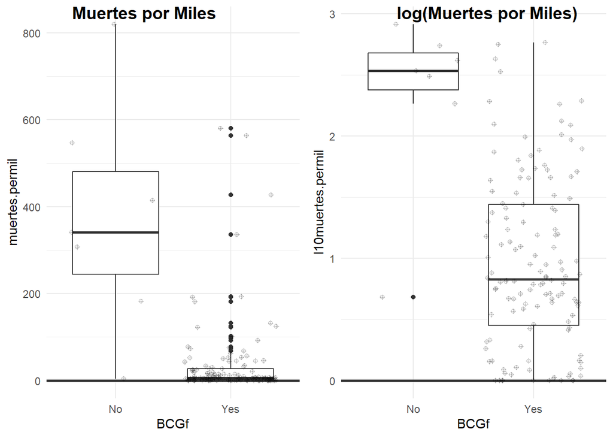

```r
g1 <- ggplot(df, aes(x= BCGf, y = muertes.permil)) +
  geom_boxplot() +
  geom_hline(yintercept = 0, size = 1, color = "#333333") +
  geom_vline(xintercept = 0, size = 1, color = "#333333") +
  theme_minimal()+
  geom_jitter(shape=10,
              position=position_jitter(),
              alpha = 0.3)

g2 <- ggplot(df, aes(x= BCGf, y = l10muertes.permil)) +
  geom_boxplot() +
  geom_hline(yintercept = 0, size = 1, color = "#333333") +
  geom_vline(xintercept = 0, size = 1, color = "#333333") +
  theme_minimal()+
  geom_jitter(shape=10,
              position=position_jitter(),
              alpha = 0.3)

ggarrange(g1, g2,
          labels = c("Muertes por Miles", "log(Muertes por Miles)"),
          ncol = 2, nrow = 1)
```

Aplicar el logaritmo nos ayuda a “compactar” la escala, sin afectar las medidas basadas en el orden de los datos. Podemos así mantener las proporciones (es decir, las diferencias proporcionales) constantes, cambiando a una escala más compacta que al mismo tiempo refleje las diferencias que están presentes en los datos originales. Además, en lo que respecta al supuesto de normalidad de los residuos, su incomplimiento puede desaconsejar el uso de pruebas de contraste, como es el caso del análisis de la varianza (ANOVA) (los cuales precisan que la distribución sea Normal). En estos casos, una de las posibles soluciones sería transformar las variables con un logaritmo (algo frecuente, por ejemplo, en el campo de la Biología).

# 5 Ejercicio n°2

Hacer un análisis exploratorio con el resto de las variables.

Vemos Correlaciones

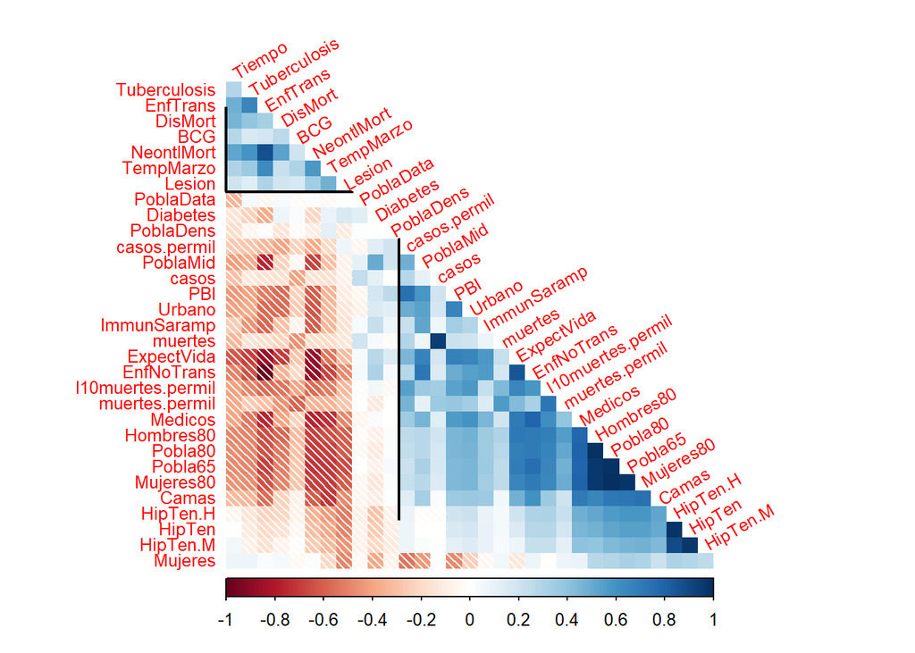

```r
corrplot(cor(select_if(df,is.numeric)), method = 'shade', order = 'AOE',
         diag = FALSE,tl.cex = 0.8,tl.srt = 30,type = "lower") %>%
  corrRect(index = c(1,8)) %>%
  corrRect(index = c(12,31))
```

Podemos destacar que hay grupos de variables que tienen correlaciones altas y en sentidos contrarios como son los casos de las variables de población (por ej: Hombres80, Mujeres80 y Pobla80) y el caso de algunas enfermedades (por ej: transmisibles y no transmisibles).

Vemos Correlaciones más importantes

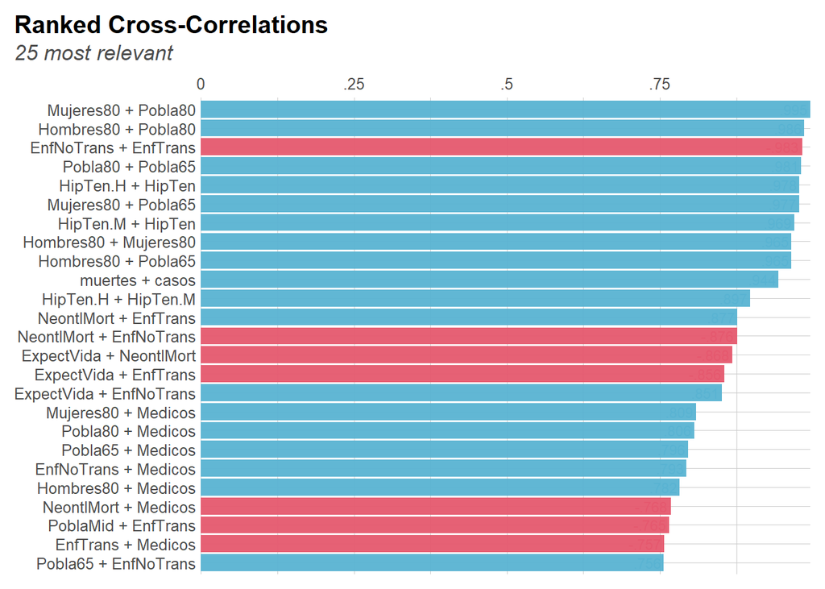

```r
corr_cross(df,type = 1, top = 25)
```

Vemos Boxplots e Histogramas por Variable

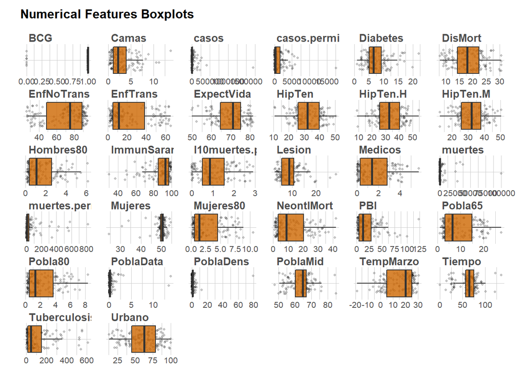

```r
lares::plot_df(select_if(df,is.numeric)) # Si no filtramos, la categórica nos come la mitad del gráfico
```

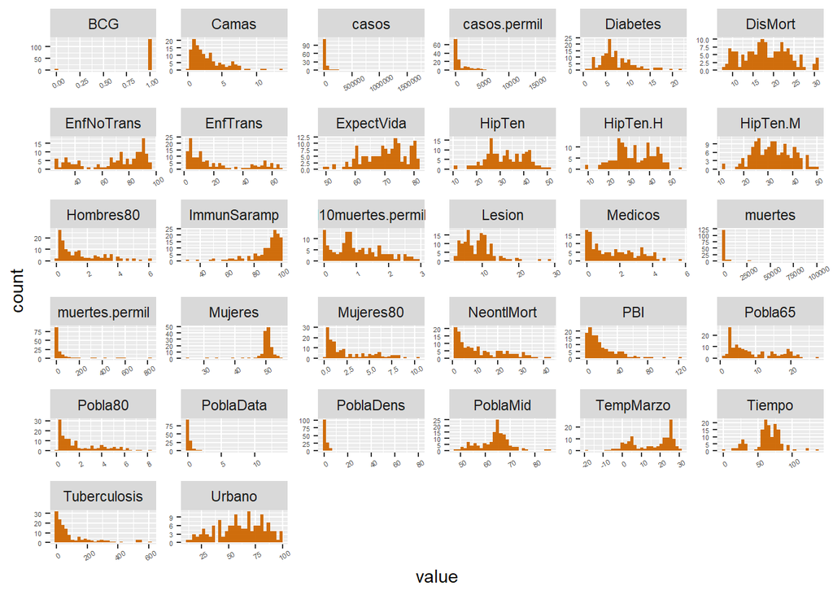

```r
base_hist = select_if(df,is.numeric)
base_hist %>%
  keep(is.numeric) %>%
  gather() %>%
  ggplot(aes(value)) +
  facet_wrap(~ key, scales = "free") +
  geom_histogram()+
  theme(axis.text.x = element_text(angle = 30,size=4),axis.text.y=element_text(size=4))
```

```r
#dev.off()
```

Respecto a las distribuciones de los datos por separado, encontramos por un lado hay algunas variables que parecen tener una distribución aproximadamente simétrica (como por ejemplo son los casos de hipertensión, población urbana y la mortalidad por enfermedades cardiovasculares, de cáncer, de diabetes o renales). En segundo lugar, tenemos variables con marcadas asimetrías y con una estructura que nos recuerdan a ciertas distribuciones estudiadas (como es el caso del PBI, que parece seguir una distribución chi-cuadrado). Y en tercer y último lugar, encontramos variables que son asimétricas a las cuales no les reconocemos parentezco con alguna distribución conocida (como es el caso de las enfermedades transmisibles).

# 6 Ejercicio n°3

Considerando únicamente como variables regresoras PoblaDens, Pobla80,Urbano, Tuberculosis, Camas, TempMarzo, PBI

1. Ajustar un modelo lineal para predecir las muertes, elegir como variable de respuesta la que resulta más adecuada.

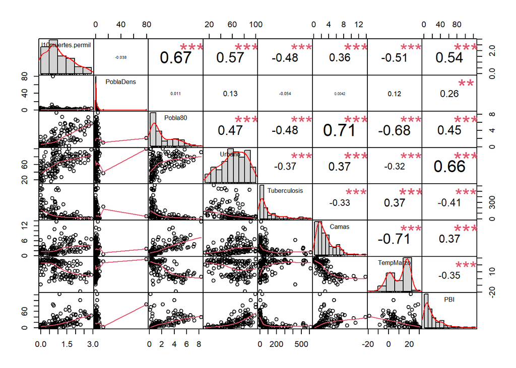

```r
base_model= subset(df,select = c("l10muertes.permil","PoblaDens","Pobla80","Urbano","Tuberculosis","Camas","TempMarzo","PBI"))

chart.Correlation(base_model, histogram = T, pch = 19)
```

```r
help(chart.Correlation)
```

```r
reg0 = lm(formula = l10muertes.permil ~ ., data = base_model)
reg1 = lm(formula = l10muertes.permil ~ PoblaDens +
            Pobla80 +
            #Urbano +
            Tuberculosis +
            Camas +
            TempMarzo +
            PBI, data = base_model)
summary(reg0)
```

```
##
## Call:
## lm(formula = l10muertes.permil ~ ., data = base_model)
##
## Residuals:
##      Min       1Q   Median       3Q      Max
## -1.08088 -0.29012 -0.03314  0.27929  1.29267
##
## Coefficients:
##                Estimate Std. Error t value Pr(>|t|)
## (Intercept)   0.5981046  0.2012630   2.972  0.00352 **
## PoblaDens    -0.0111873  0.0063386  -1.765  0.07990 .
## Pobla80       0.2040913  0.0338369   6.032 1.55e-08 ***
## Urbano        0.0082702  0.0025767   3.210  0.00167 **
## Tuberculosis -0.0005815  0.0003431  -1.695  0.09246 .
## Camas        -0.1101291  0.0263087  -4.186 5.17e-05 ***
## TempMarzo    -0.0143117  0.0057068  -2.508  0.01337 *
## PBI           0.0062466  0.0027181   2.298  0.02314 *
## ---
## Signif. codes:  0 '***' 0.001 '**' 0.01 '*' 0.05 '.' 0.1 ' ' 1
##
## Residual standard error: 0.4765 on 131 degrees of freedom
## Multiple R-squared:  0.6239, Adjusted R-squared:  0.6038
## F-statistic: 31.04 on 7 and 131 DF,  p-value: < 2.2e-16
```

```r
summary(reg1)
```

```
##
## Call:
## lm(formula = l10muertes.permil ~ PoblaDens + Pobla80 + Tuberculosis +
##     Camas + TempMarzo + PBI, data = base_model)
##
## Residuals:
##      Min       1Q   Median       3Q      Max
## -1.01093 -0.36501 -0.01228  0.28074  1.36328
##
## Coefficients:
##                Estimate Std. Error t value Pr(>|t|)
## (Intercept)   0.9471756  0.1752109   5.406 2.92e-07 ***
## PoblaDens    -0.0121371  0.0065510  -1.853 0.066158 .
## Pobla80       0.2217879  0.0345408   6.421 2.25e-09 ***
## Tuberculosis -0.0006614  0.0003540  -1.868 0.063941 .
## Camas        -0.1060362  0.0271879  -3.900 0.000152 ***
## TempMarzo    -0.0130745  0.0058910  -2.219 0.028166 *
## PBI           0.0110011  0.0023579   4.666 7.45e-06 ***
## ---
## Signif. codes:  0 '***' 0.001 '**' 0.01 '*' 0.05 '.' 0.1 ' ' 1
##
## Residual standard error: 0.493 on 132 degrees of freedom
## Multiple R-squared:  0.5943, Adjusted R-squared:  0.5759
## F-statistic: 32.23 on 6 and 132 DF,  p-value: < 2.2e-16
```

Ahora bien, para elegir la variable de respuesta más adecuada también hacemos el ejercicio de comparar el modelo con la variable muertes en valores nominales por un lado y con muertes en escala logarítmica por otro lado para analizar sus residuos.

```r
regmuertes = lm(formula = muertes.permil ~ .-l10muertes.permil, data = df[,c("muertes.permil","l10muertes.permil","PoblaDens","Pobla80","Urbano","Tuberculosis","Camas","TempMarzo","PBI")])
```

```r
regmuertes_log = lm(formula = l10muertes.permil ~ ., data = df[,c("l10muertes.permil","PoblaDens","Pobla80","Urbano","Tuberculosis","Camas","TempMarzo","PBI")])
```

Graficamos los residuos en ambos casos:

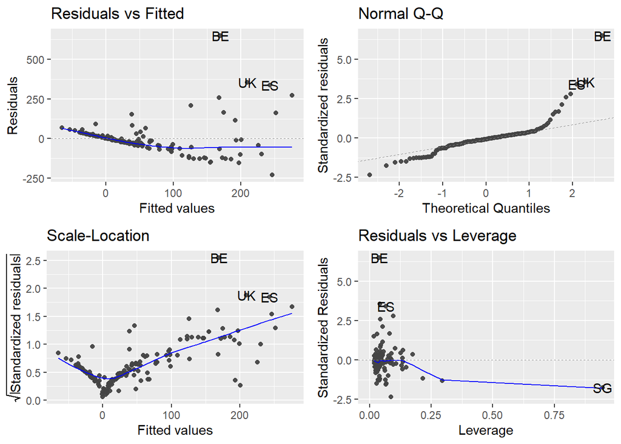

```r
library("ggfortify")
autoplot(regmuertes)
```

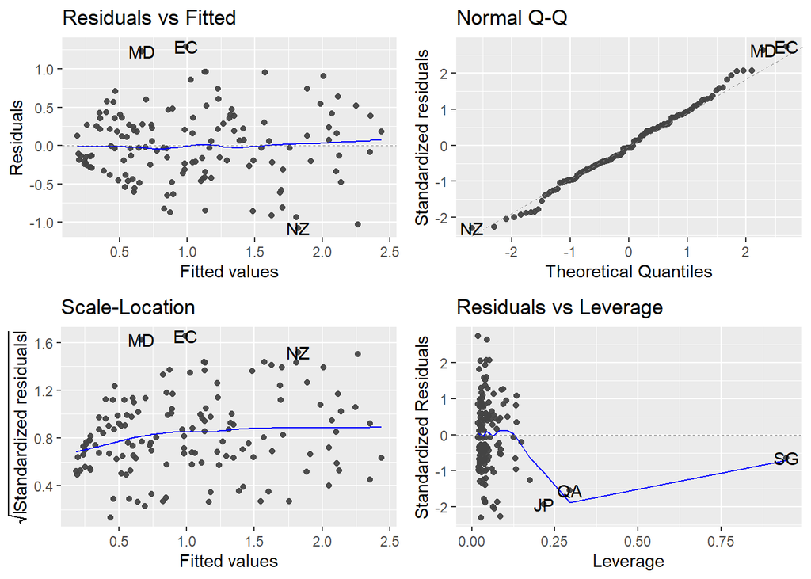

```r
autoplot(regmuertes_log)
```

Encontramos más conveniente utilizar la variable de respuesta muertes en logaritmo puesto que muestran una distribución mucho más similar a la de una normal, al mismo tiempo que los residuos se muestran sin estructura. De manera complementaria, un test de KS de normalidad a su vez nos da bastante fuerza en nuestro análisis visual, puesto que nos da un p-valor bastante elevado y nos permite no rechazar la hipótesis nula holgadamente.

```r
ks.test(regmuertes_log$residuals,"pnorm",mean(regmuertes_log$residuals),sd(regmuertes_log$residuals))
```

```
##
##  Asymptotic one-sample Kolmogorov-Smirnov test
##
## data:  regmuertes_log$residuals
## D = 0.048945, p-value = 0.8931
## alternative hypothesis: two-sided
```

```r
n = nrow(df)
p = length(reg0$coefficients) - 1
which((cooks.distance(reg0)>pf(p,n-p,0.5)) == TRUE)
```

```
##  SG
## 116
```

Con la misma noción de distancia, podemos usar la librería *oslrr*, la cuál utiliza un threshold de $4/n$ para determinar si una observación es un potencial outlier, en función de su leverage.

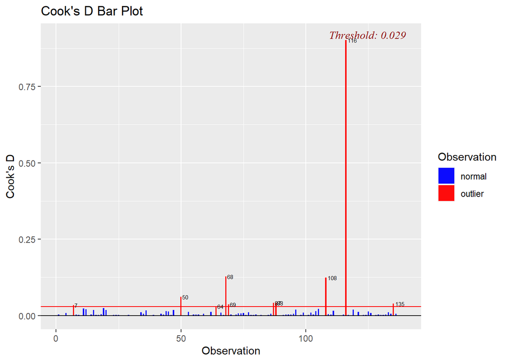

```r
ols_plot_cooksd_bar(model = reg0)
```

```r
which((cooks.distance(reg0)>0.029) == TRUE)
```

```
##  AU  EL  IE  JP  JO  MD  MN  QA  SG  UY
##   7  50  64  68  69  87  88 108 116 135
```

```r
# Vemos los nombres de los países completos
(df[as.vector(which((cooks.distance(reg0)>0.029) == TRUE)),"CntrName"])
```

```
##  [1] "Australia" "Greece"    "Ireland"   "Japan"     "Jordan"    "Moldova"
##  [7] "Mongolia"  "Qatar"     "Singapore" "Uruguay"
```

Australia, Grecia, Irlanda, Japón, Jordania, Moldavia, Mongolia, Qatar, Singapur y Uruguay.

Respecto a la influencia, encontramos tres países que son particularmente influyentes:

- Japón
- Qatar
- Singapur

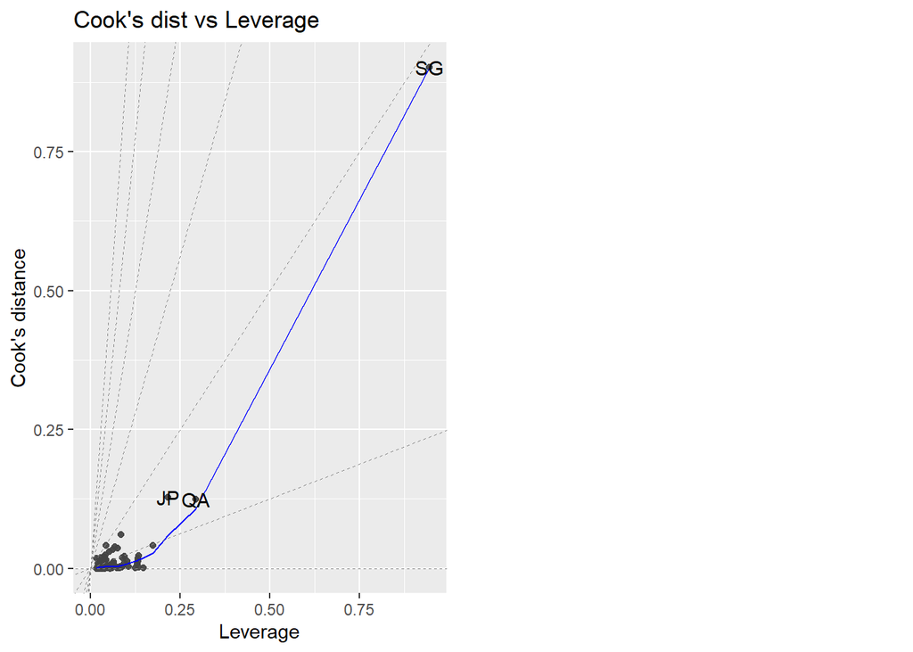

```r
autoplot(reg0,which = 6)
```

Hasta el momento parece bastante claro que nos conviene utilizar la variable de respuesta medida en logaritmos. Sin embargo, notamos que hay potenciales outliers que saltan a la vista a pesar de utilizar diferentes criterios de corte en el análisis de leverage. Es por esto último que consideramos implementar una regresión robusta.

```r
library("RobStatTM")

cont <- lmrobdet.control(bb= 0.5, efficiency= 0.85, family= "bisquare")
lm_MM = lmrobdetMM(formula = l10muertes.permil ~ ., data = df[,c("l10muertes.permil","PoblaDens","Pobla80","Urbano","Tuberculosis","Camas","TempMarzo","PBI")], control=cont)
```

```r
# Vemos salida Robusta
summary(lm_MM)
```

```
##
## Call:
## lmrobdetMM(formula = l10muertes.permil ~ ., data = df[, c("l10muertes.permil",
##     "PoblaDens", "Pobla80", "Urbano", "Tuberculosis", "Camas", "TempMarzo",
##     "PBI")], control = cont)
## Residuals:
##      Min       1Q   Median       3Q      Max
## -1.24220 -0.27260 -0.03026  0.31517  1.31445
##
## Coefficients:
##                Estimate Std. Error t value Pr(>|t|)
## (Intercept)   0.3849847  0.2222787   1.732  0.08563 .
## PoblaDens    -0.0125395  0.0063513  -1.974  0.05045 .
## Pobla80       0.2524079  0.0373247   6.762 4.07e-10 ***
## Urbano        0.0091258  0.0027644   3.301  0.00124 **
## Tuberculosis -0.0004969  0.0003576  -1.390  0.16697
## Camas        -0.1163727  0.0286581  -4.061 8.37e-05 ***
## TempMarzo    -0.0091945  0.0063197  -1.455  0.14809
## PBI           0.0060534  0.0029396   2.059  0.04145 *
## ---
## Signif. codes:  0 '***' 0.001 '**' 0.01 '*' 0.05 '.' 0.1 ' ' 1
##
## Robust residual standard error: 0.4764
## Multiple R-squared:  0.6361, Adjusted R-squared:  0.6166
## Convergence in 25 IRWLS iterations
```

```r
# Vemos salida No-Robusta
summary(regmuertes_log)
```

```
##
## Call:
## lm(formula = l10muertes.permil ~ ., data = df[, c("l10muertes.permil",
##     "PoblaDens", "Pobla80", "Urbano", "Tuberculosis", "Camas",
##     "TempMarzo", "PBI")])
##
## Residuals:
##      Min       1Q   Median       3Q      Max
## -1.08088 -0.29012 -0.03314  0.27929  1.29267
##
## Coefficients:
##                Estimate Std. Error t value Pr(>|t|)
## (Intercept)   0.5981046  0.2012630   2.972  0.00352 **
## PoblaDens    -0.0111873  0.0063386  -1.765  0.07990 .
## Pobla80       0.2040913  0.0338369   6.032 1.55e-08 ***
## Urbano        0.0082702  0.0025767   3.210  0.00167 **
## Tuberculosis -0.0005815  0.0003431  -1.695  0.09246 .
## Camas        -0.1101291  0.0263087  -4.186 5.17e-05 ***
## TempMarzo    -0.0143117  0.0057068  -2.508  0.01337 *
## PBI           0.0062466  0.0027181   2.298  0.02314 *
## ---
## Signif. codes:  0 '***' 0.001 '**' 0.01 '*' 0.05 '.' 0.1 ' ' 1
##
## Residual standard error: 0.4765 on 131 degrees of freedom
## Multiple R-squared:  0.6239, Adjusted R-squared:  0.6038
## F-statistic: 31.04 on 7 and 131 DF,  p-value: < 2.2e-16
```

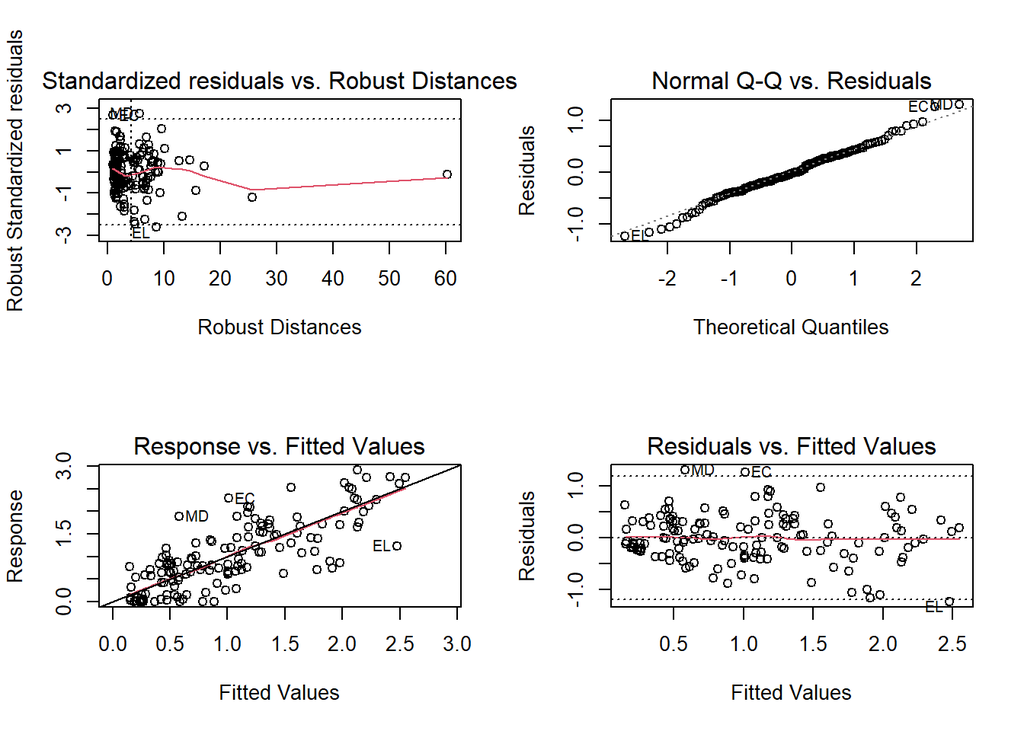

```r
# Graficamos Residuos del Modelo Robusto

par(mfrow=c(2,2))
plot(lm_MM) # regmuertes_log
```